# Sulawesi Selatan dalam Angka Visual

Membaca IPM dan kemiskinan di Sulawesi Selatan, 2022–2024

Penulis

Tim 1 - Komputasi Statistika Lanjut

Diterbitkan

10 Oktober 2026

**TIM 1**  
NATHANIA OKTAVIA GUNAWAN · H062261002  
DHIYA IZDIHAR HARYADI · H062261003

Atlas ini menyajikan dua indikator yang saling melengkapi: Indeks Pembangunan Manusia (IPM) sebagai gambaran capaian pembangunan manusia dan persentase penduduk miskin sebagai konteks kesejahteraan ekonomi. Fokus pembacaan adalah perubahan antarwaktu dan perbedaan antarwilayah, bukan sekadar urutan peringkat.

# 1 Intisari

Data mencakup **`24` kabupaten/kota selama tiga tahun (`2022–2024`)** atau `72` observasi wilayah-tahun. Secara agregat, rata-rata IPM meningkat dari `73,13` pada `2022` menjadi `74,49` pada `2024`. Pada periode yang sama, rata-rata persentase penduduk miskin turun dari `9,32%` menjadi `8,60%`. Perubahan rata-rata ini memberi gambaran umum, tetapi tidak berarti setiap wilayah mengalami perubahan dengan besaran atau arah yang sama.

Ringkasan rata-rata indikator per tahun

| tahun | Rata-rata IPM | Rata-rata penduduk miskin (%) |
| --- | --- | --- |
| 2022 | 73.13 | 9.32 |
| 2023 | 73.84 | 9.33 |
| 2024 | 74.49 | 8.60 |

**Catatan**

**Cara membaca atlas.** Gunakan grafik untuk melihat distribusi dan pola, peta untuk memahami konteks geografis, profil untuk menelusuri wilayah tertentu, serta interval bootstrap dan lineup untuk membaca ketidakpastian. Pola visual menunjukkan asosiasi, bukan bukti sebab-akibat.

# 2 Dari grafik awal ke desain yang lebih informatif

Makeover mengutamakan hierarki informasi yang jelas, label yang langsung menjelaskan pesan, dan penekanan warna yang terbatas. Grafik awal dan hasil perbaikan ditampilkan berdampingan agar alasan perubahan desain dapat dievaluasi.

### 2.0.1 Sebelum

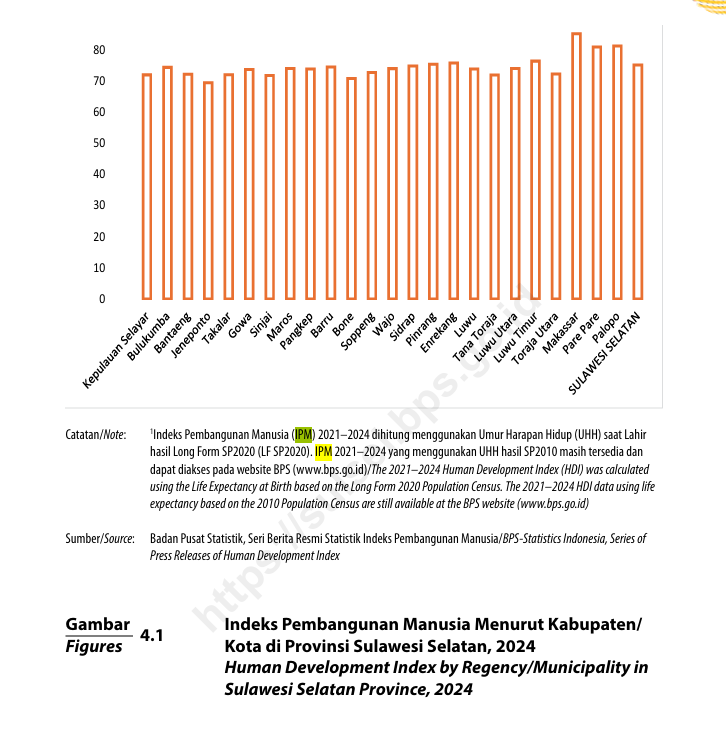

### 2.0.2 Sesudah

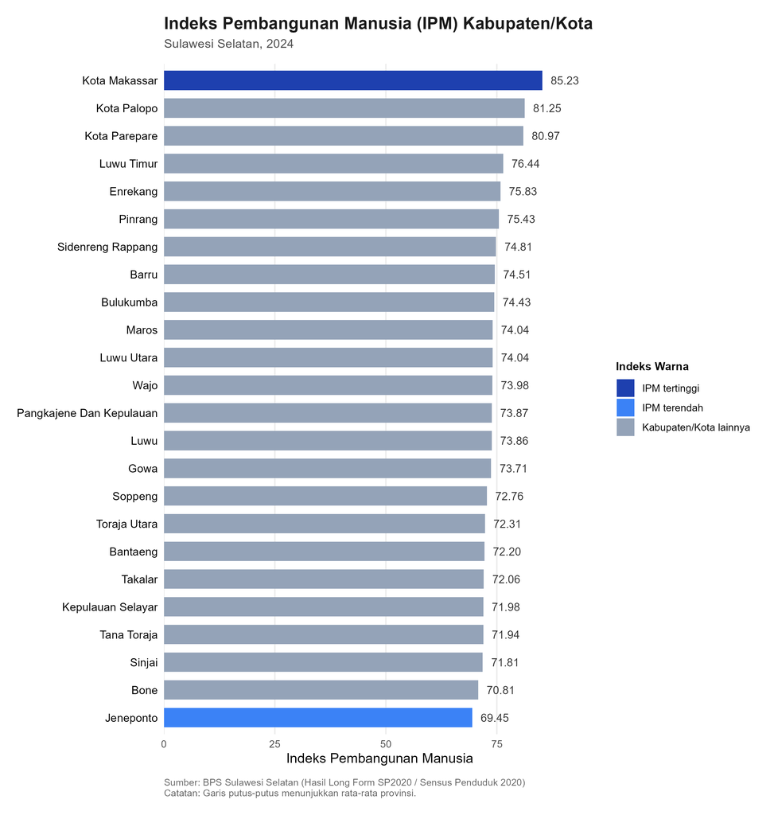

**Prinsip desain:** kurangi elemen dekoratif yang tidak membantu pembacaan, gunakan warna secara konsisten, perjelas judul dan sumber, serta pertahankan konteks pembanding. Palet dan tema khusus proyek disimpan di `R/04_theme_palet_tim.R` agar dapat digunakan kembali.

# 3 Galeri Statistik

Galeri berikut memadukan distribusi, perubahan waktu, hubungan dua indikator, peringkat, dan ringkasan multipanel. Setiap grafik menjawab pertanyaan yang berbeda; karena itu, satu grafik tidak diperlakukan sebagai pengganti seluruh analisis.

## 3.1 1. Sebaran IPM

Grafik ini membantu membandingkan rentang dan variasi IPM antardaerah selama periode pengamatan.

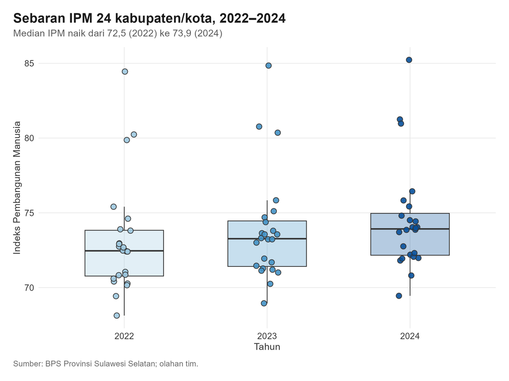

## 3.2 2. Perubahan IPM Antarwaktu

Grafik tren menempatkan tahun sebagai urutan waktu sehingga perubahan tiap wilayah lebih mudah ditelusuri daripada hanya membandingkan satu tahun.

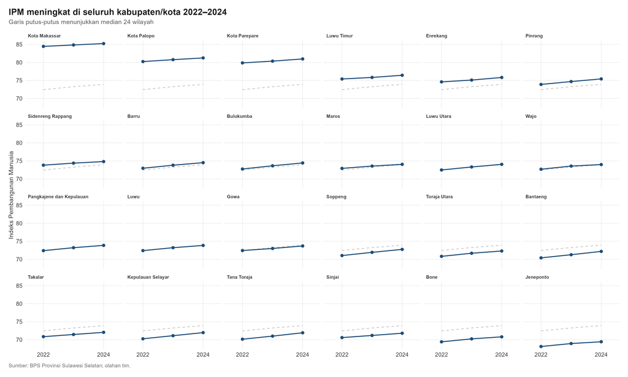

## 3.3 3. Hubungan IPM dan Kemiskinan

Titik mewakili kabupaten/kota, sedangkan bentuk membedakan kelompok kabupaten dan kota. Garis tren membantu merangkum arah hubungan linear. Hubungan negatif yang tampak pada grafik perlu dibaca sebagai asosiasi deskriptif; faktor lain dan struktur tiap wilayah tidak dikendalikan oleh grafik ini.

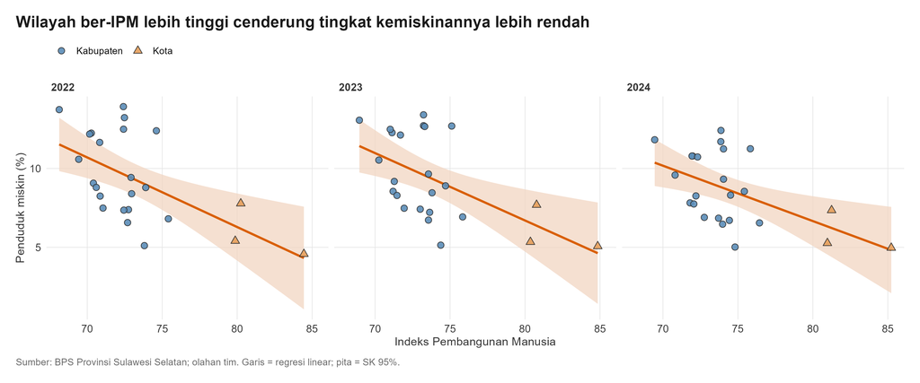

## 3.4 4. Peringkat IPM

Peringkat menonjolkan posisi relatif wilayah, tetapi selisih nilai antarwilayah tetap perlu diperhatikan. Perubahan urutan kecil tidak selalu berarti perubahan capaian yang besar.

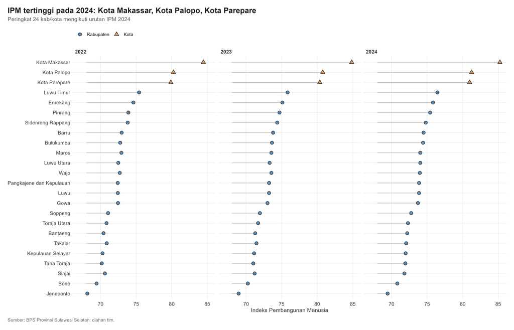

## 3.5 5. Ringkasan Multipanel

Multipanel merangkum beberapa sudut pandang dalam satu halaman. Baca tiap panel sesuai judul dan sumbu; hindari membandingkan jarak visual antarpanel bila skala sumbunya berbeda.

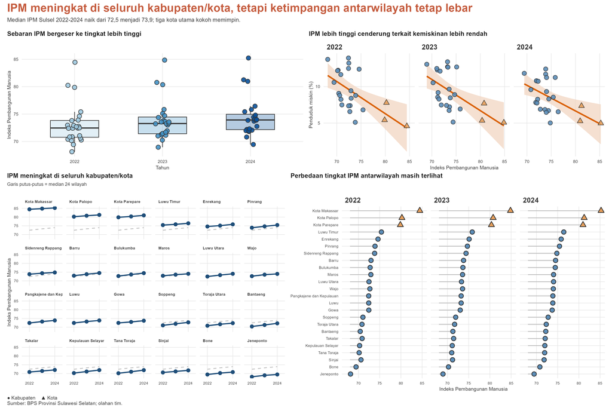

# 4 Peta: Melihat Konteks Wilayah

Peta membantu mengenali pola spasial yang tidak selalu terlihat pada tabel peringkat. Data batas administratif bersumber dari geoBoundaries ADM2 yang telah disederhanakan untuk kebutuhan visualisasi. Peta koroplet menunjukkan variasi nilai indikator, bukan batas sebab-akibat atau penjelasan mengapa suatu wilayah memiliki nilai tertentu.

### 4.0.1 IPM

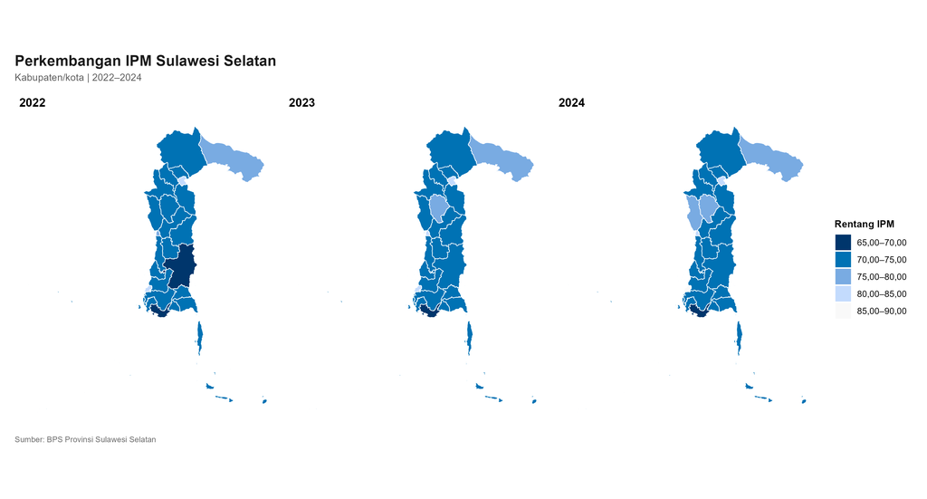

### 4.0.2 Penduduk Miskin

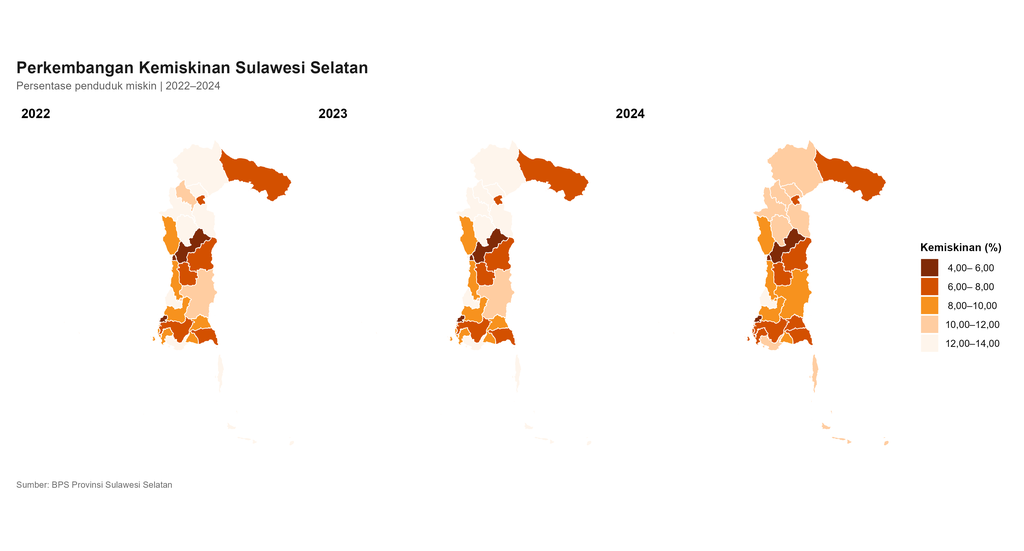

## 4.1 Pemeriksaan Aksesibilitas Warna

Versi pemeriksaan palet untuk tahun `2024` disertakan sebagai bahan evaluasi keterbedaan warna. Peta tematik sebaiknya tidak mengandalkan warna saja: legenda, label, dan konteks tahun tetap penting bagi pembaca dengan persepsi warna yang berbeda.

### 4.1.1 IPM · 2024

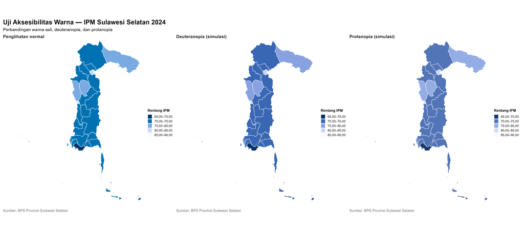

### 4.1.2 Penduduk Miskin · 2024

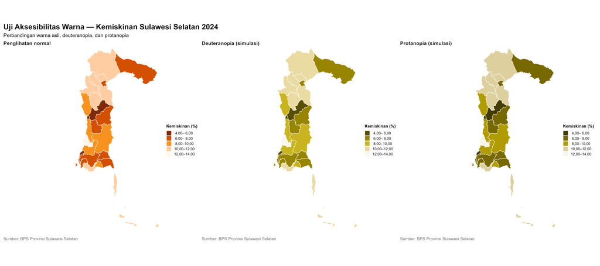

# 5 Jelajahi 24 Kabupaten/kota

Profil wilayah menggabungkan informasi IPM dan kemiskinan untuk membantu pembaca beralih dari gambaran provinsi ke konteks lokal. Gunakan profil sebagai ringkasan eksploratif, bukan sebagai penilaian tunggal atas keberhasilan pembangunan.

### 5.0.1 Bantaeng

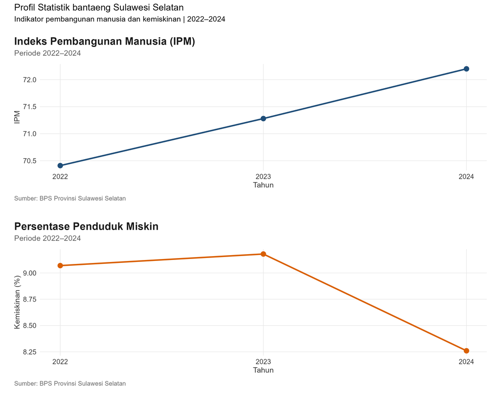

### 5.0.2 Barru

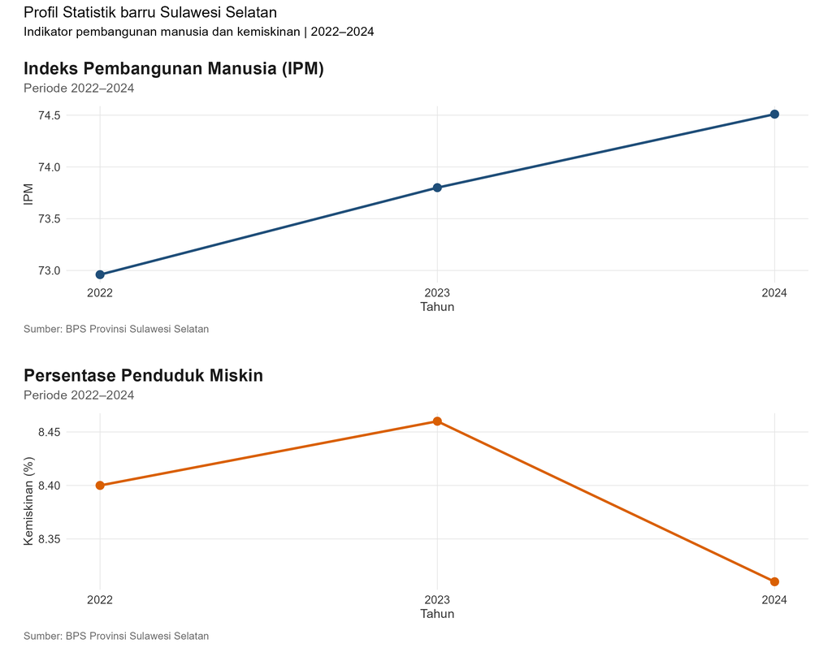

### 5.0.3 Bone

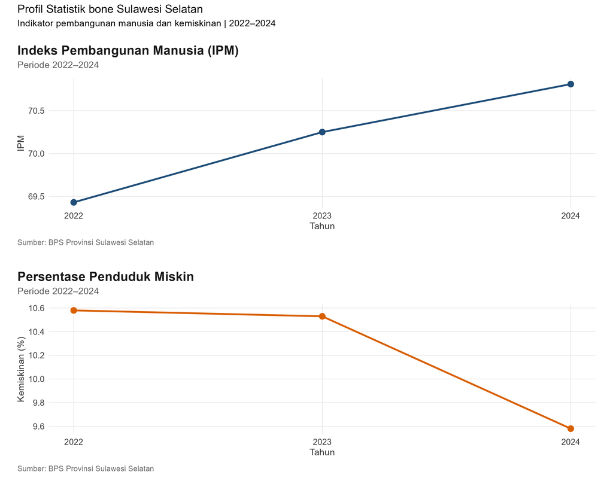

### 5.0.4 Bulukumba

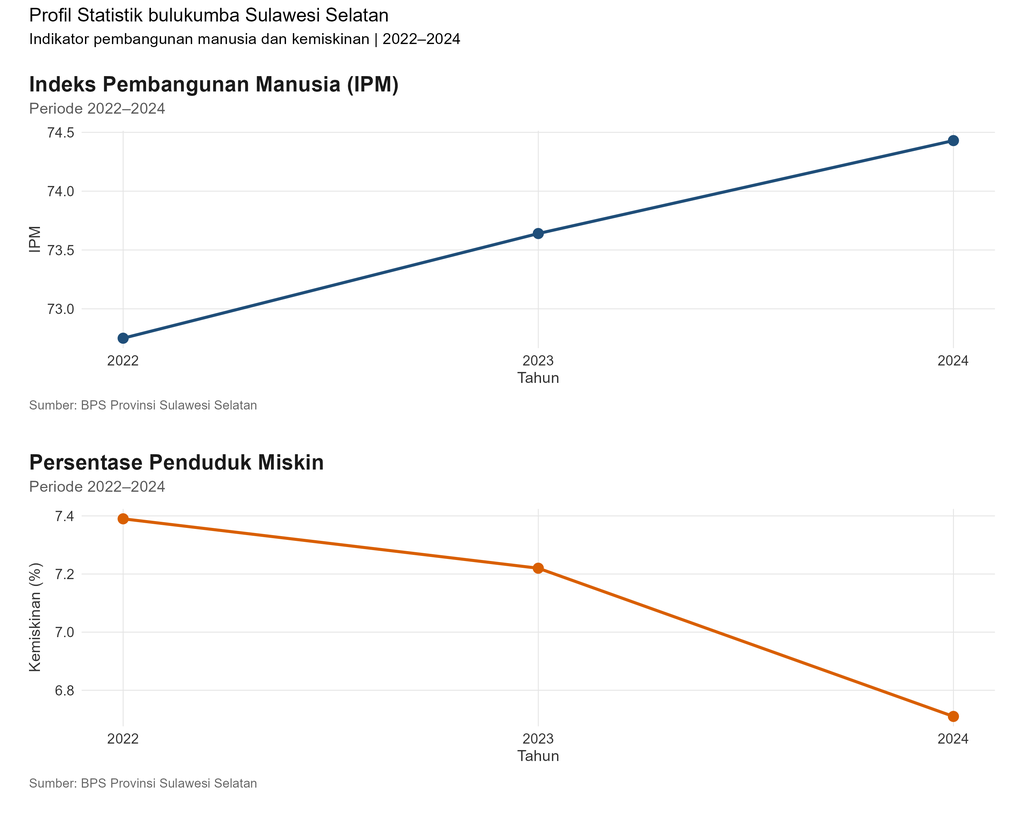

### 5.0.5 Enrekang

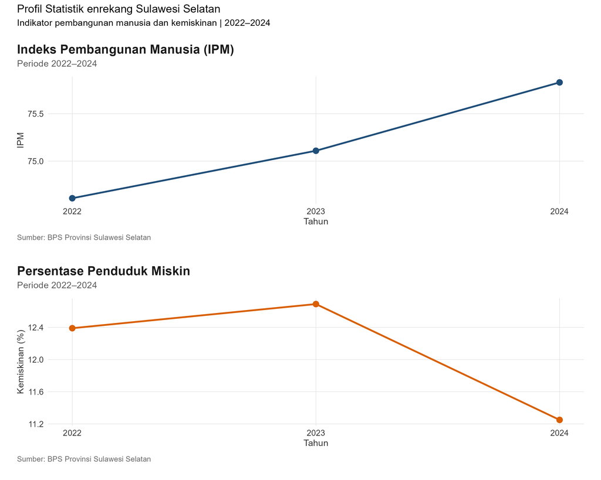

### 5.0.6 Gowa

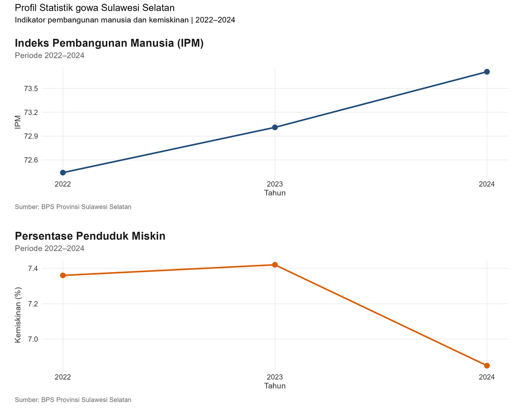

### 5.0.7 Jeneponto

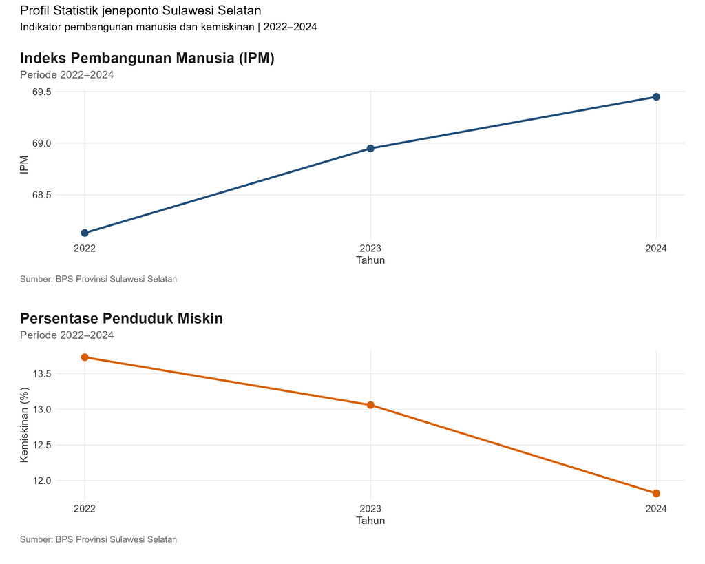

### 5.0.8 Kepulauan Selayar

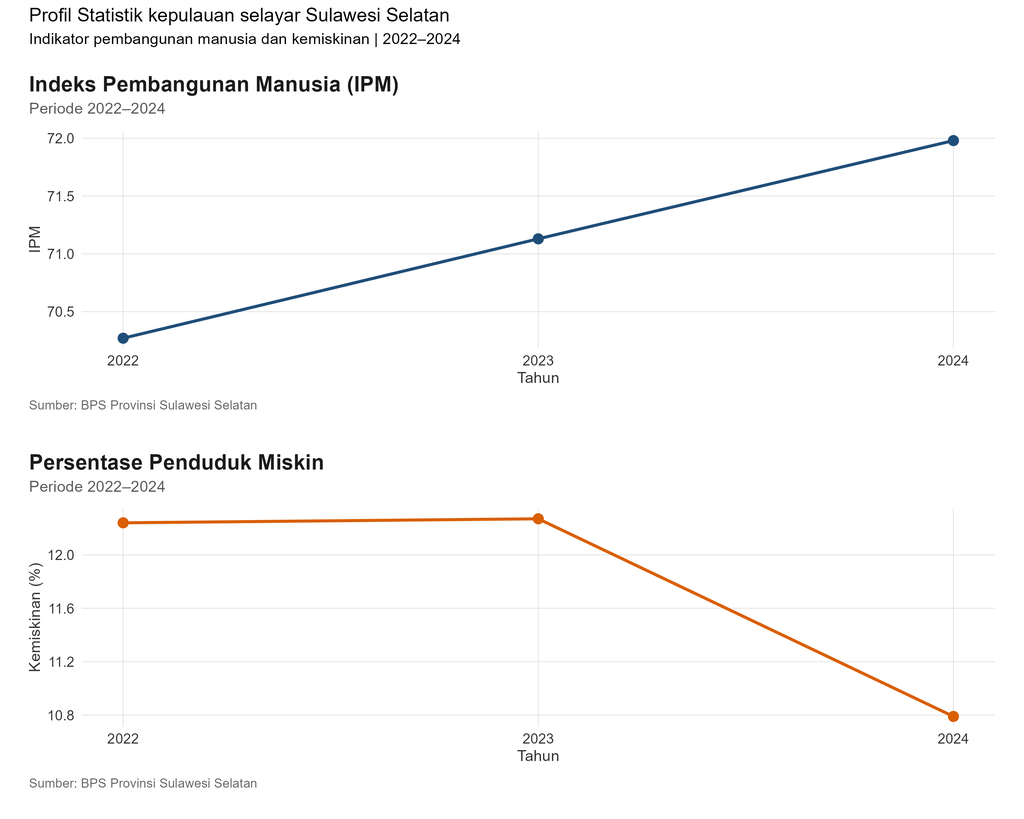

### 5.0.9 Kota Makassar

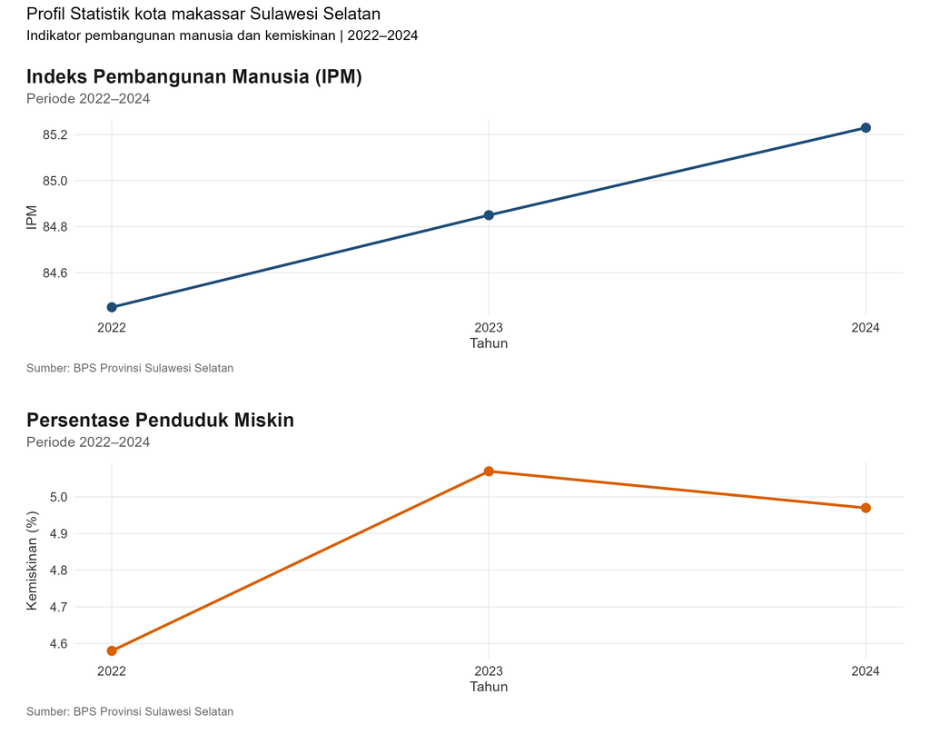

### 5.0.10 Kota Palopo

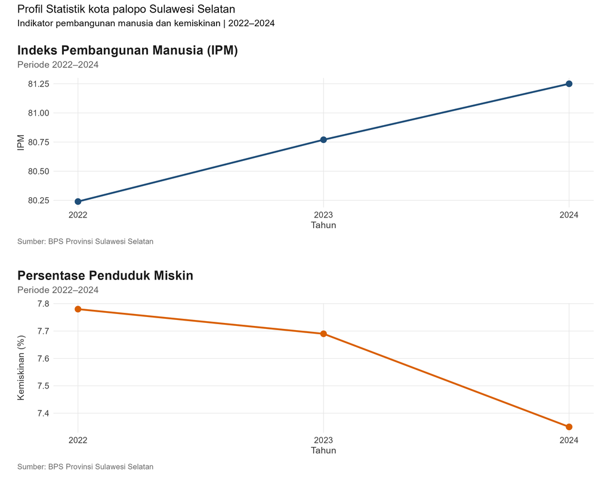

### 5.0.11 Kota Parepare

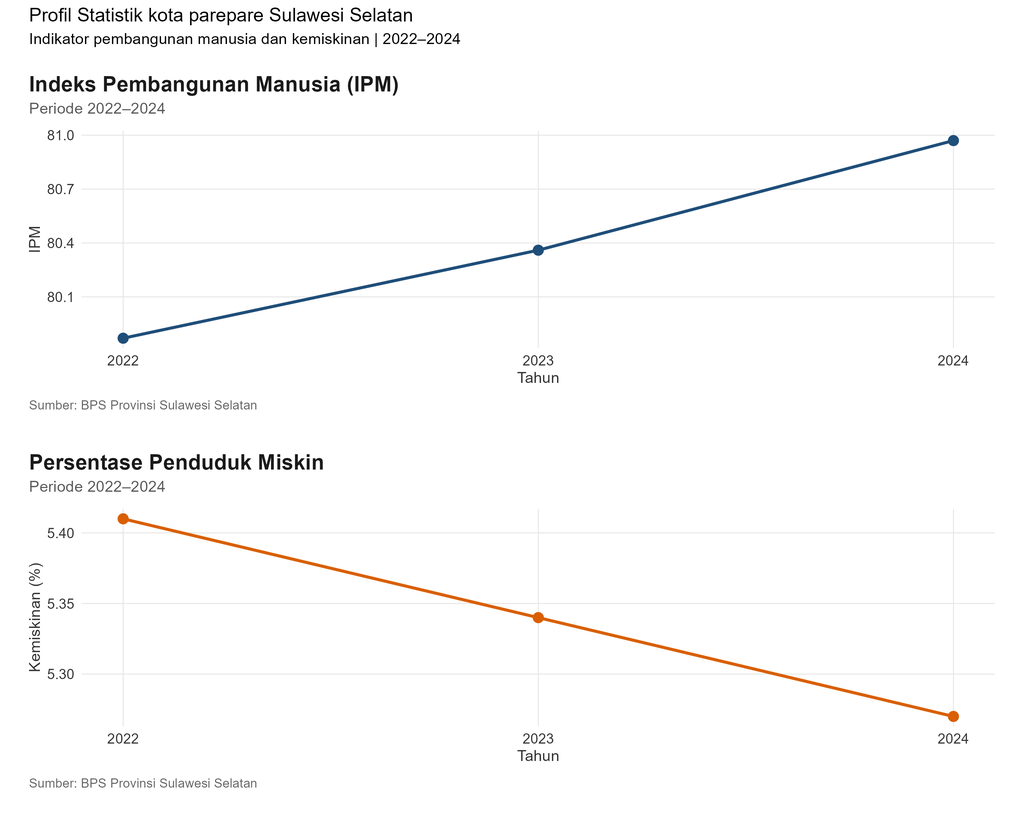

### 5.0.12 Luwu

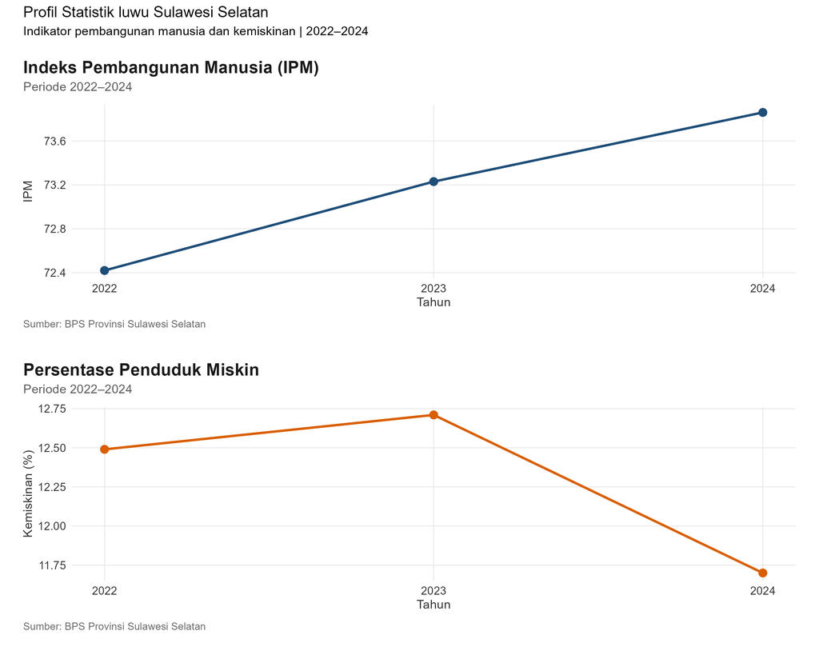

### 5.0.13 Luwu Timur

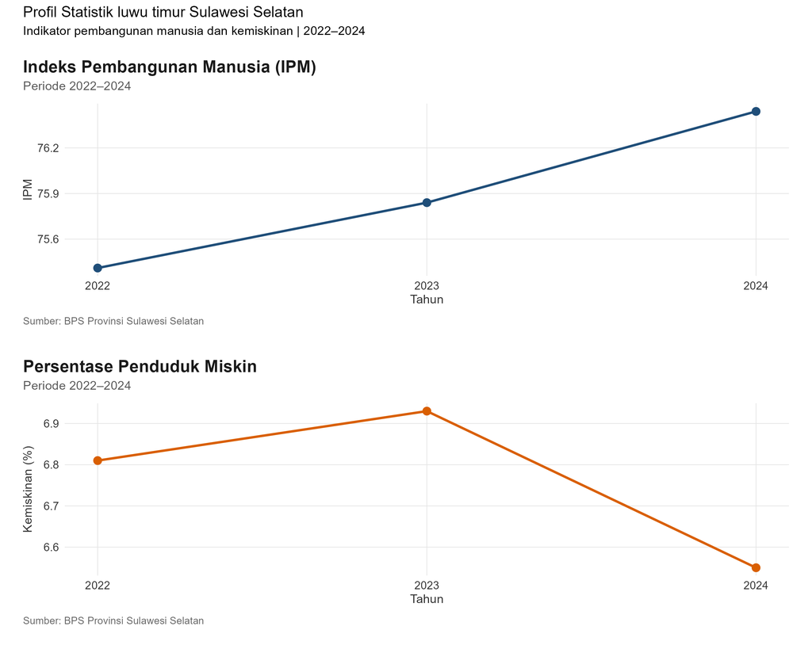

### 5.0.14 Luwu Utara

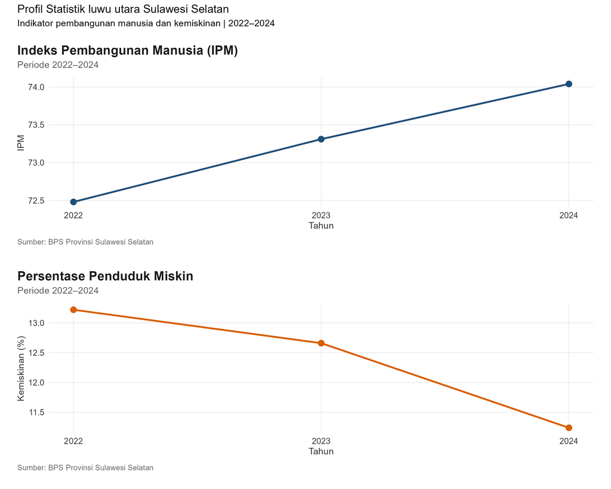

### 5.0.15 Maros

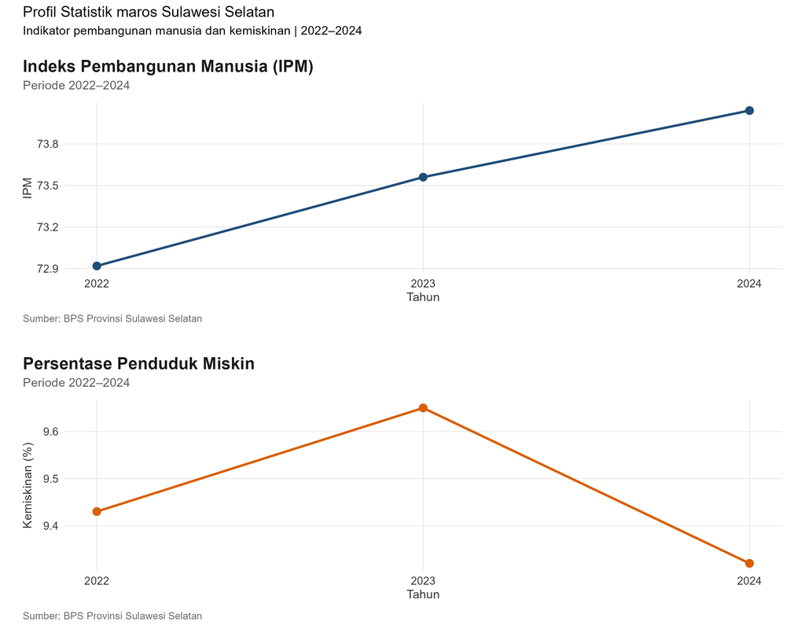

### 5.0.16 Pangkajene Dan Kepulauan

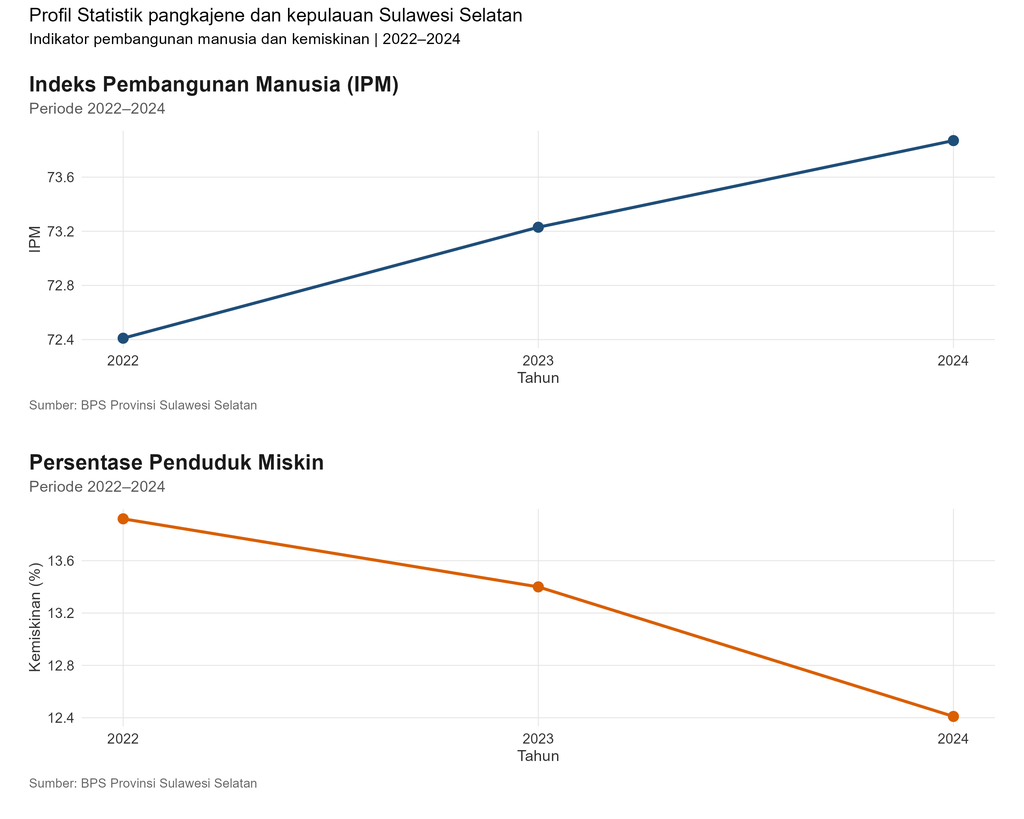

### 5.0.17 Pinrang

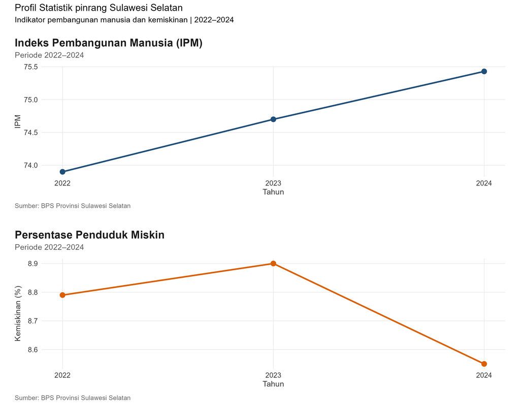

### 5.0.18 Sidenreng Rappang

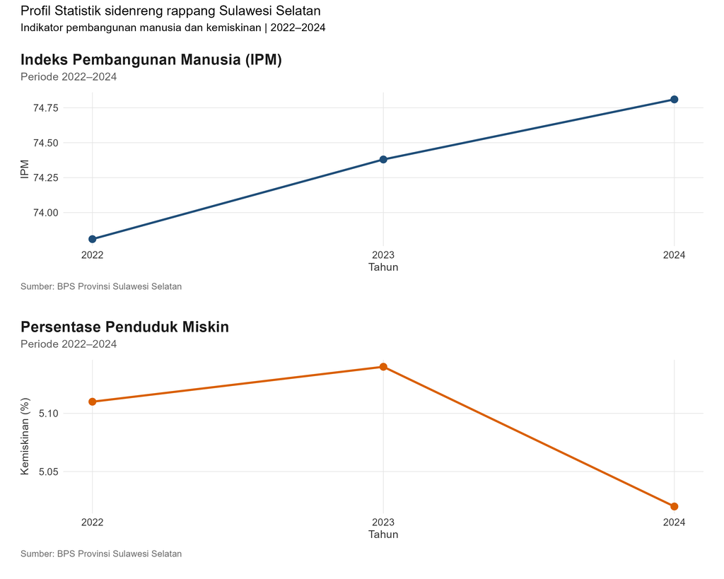

### 5.0.19 Sinjai

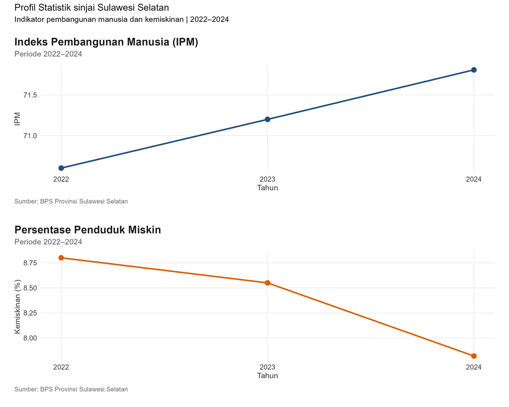

### 5.0.20 Soppeng

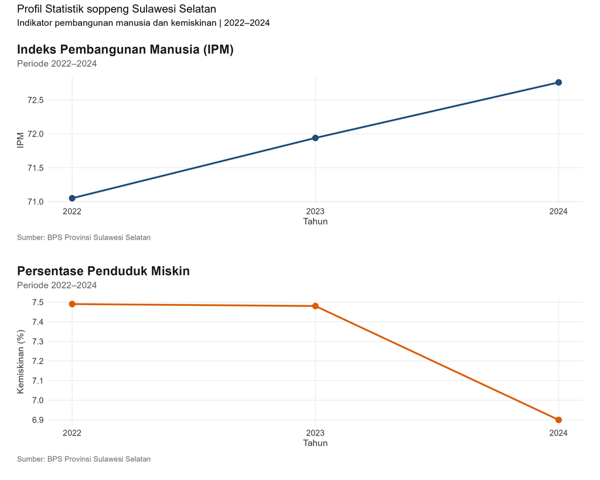